# Logistic Regression with Python

### What is Logistic Regression ?

#### It is a statistical model that in its basic form uses a logistic function to model a binary dependent variable

#### Dataset

A group of 20 students spends between 0 and 6 hours studying for an exam. How does the number of hours spent studying affect the probability of the student passing the exam?

```python
import numpy as np
import pandas as pd
import Toggle
pd.set_option('display.max_rows', 6)
df = pd.read_csv('StudyData.csv')
display(df)
Toggle.hide_toggle()
```

|  | Hours | Pass |
| --- | --- | --- |
| 0 | 0.50 | 0 |
| 1 | 0.75 | 0 |
| 2 | 1.00 | 0 |
| ... | ... | ... |
| 17 | 4.75 | 1 |
| 18 | 5.00 | 1 |
| 19 | 5.50 | 1 |

20 rows × 2 columns

S/H

##### Scatter Plot

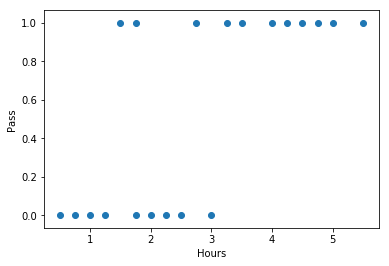

S/H

```python
import matplotlib.pyplot as plt
plt.scatter(df.Hours,df.Pass)
plt.xlabel("Hours")
plt.ylabel("Pass")
plt.show()
Toggle.hide_toggle()
```

#### $p$ = Probability of a student passing the exam

#### $x$ = Number of hours the student spent in study

### $logit$ $p$ = $ln(\frac{p}{1-p})$

#### Logistic Regression Model assumes :

### $logit$ $\hat{p}$ = $ax + b$

### $ln(\frac{\hat{p}}{1-\hat{p}})$ = $ax + b$

## $\hat{p}$ = $\frac{1}{1+e^{-(ax+b)}}$

### Basically, we are modelling $logit$ $p$ through linear regression i.e. $logit$ $\hat{p}$ = $ax+b$

Since the goal of model is the probability of a random variable Y being 0 or 1 given experimental data, consider a generalized linear model function parameterized by $\theta$,

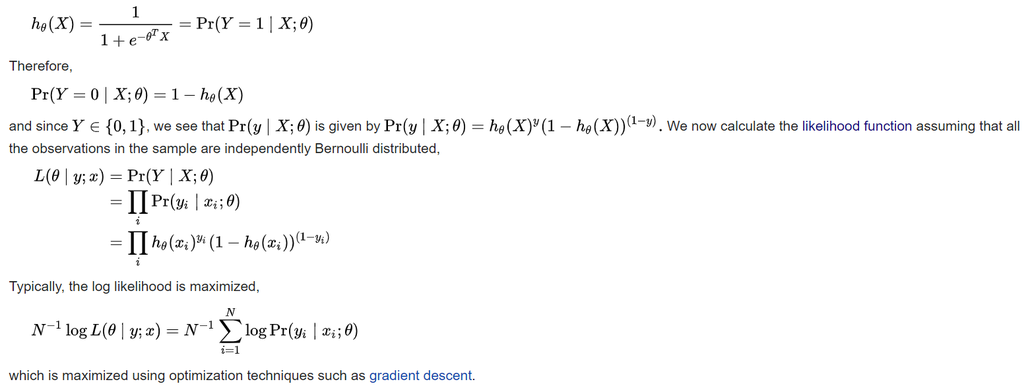

### Using Scikit-Learn (sklearn) to fit Logistic Regression Model

```
a :  1.1875
b :  -2.9148
```

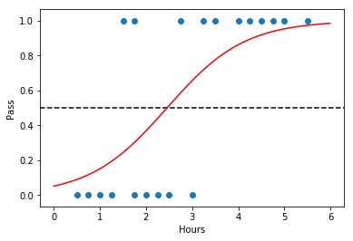

S/H

```python
from sklearn.linear_model import LogisticRegression
X = np.reshape(df.Hours.values,(-1,1))
Y = df.Pass.values
clf = LogisticRegression(solver='lbfgs',random_state=0).fit(X,Y)
a = clf.coef_[0][0]
b = clf.intercept_[0]
print('a : ',np.round(a,4))
print('b : ',np.round(b,4))
x = np.arange(0,6,.01)
y = 1/(1+np.exp(-a*x-b))
plt.scatter(df.Hours,df.Pass)
plt.axhline(0.5,color='black',linestyle='--')
plt.plot(x,y,color='red')
plt.xlabel("Hours")
plt.ylabel("Pass")
plt.show()
Toggle.hide_toggle()
```

### Metrics for evaluting fitness of binary classification model

- Classification models generally return the probability of a sample belonging to a particular class
- Binary classification model such as the logistic regression above returns probability of a sample belonging to class 1 (say p). Thus, probability of sample belonging to class 0 will be (1 - p)
- To assign a class to the sample we have to threshold on p. Let's say we choose a threshold of T for the above binary classifier
- Thus, for all the samples for which classifier gives p >= T, will be classified as class 1. And remaining (with p<T) will be classified as class 0.
- Once we have a threshold T, we can can put get number of samples in following categories (Positve means Class 1, Negative means Class 0)

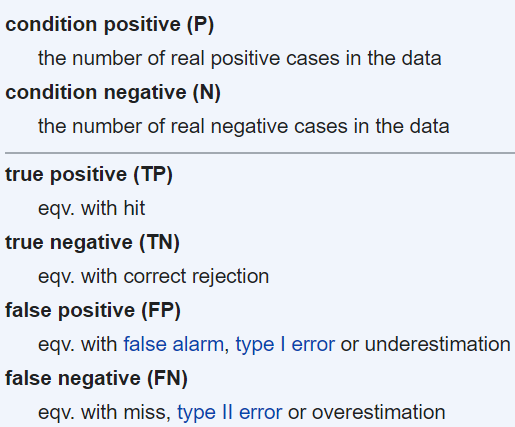

- After that following metrics can be calculated

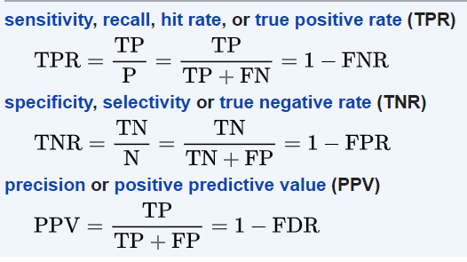

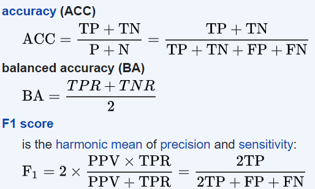

### Let's chose theshold as 0.5 for above example

|  | 0 | 1 | 2 | 3 | 4 | 5 | 6 | 7 | 8 | 9 | 10 | 11 | 12 | 13 | 14 | 15 | 16 | 17 | 18 | 19 |
| --- | --- | --- | --- | --- | --- | --- | --- | --- | --- | --- | --- | --- | --- | --- | --- | --- | --- | --- | --- | --- |
| Hours | 0.50 | 0.75 | 1.00 | 1.25 | 1.50 | 1.75 | 1.75 | 2.00 | 2.25 | 2.50 | 2.75 | 3.00 | 3.25 | 3.50 | 4.00 | 4.25 | 4.50 | 4.75 | 5.00 | 5.50 |
| Pass | 0.00 | 0.00 | 0.00 | 0.00 | 1.00 | 1.00 | 0.00 | 0.00 | 0.00 | 0.00 | 1.00 | 0.00 | 1.00 | 1.00 | 1.00 | 1.00 | 1.00 | 1.00 | 1.00 | 1.00 |
| Pass Prob. Predicted | 0.09 | 0.12 | 0.15 | 0.19 | 0.24 | 0.30 | 0.30 | 0.37 | 0.44 | 0.51 | 0.59 | 0.66 | 0.72 | 0.78 | 0.86 | 0.89 | 0.92 | 0.94 | 0.95 | 0.97 |
| Prediction | 0.00 | 0.00 | 0.00 | 0.00 | 0.00 | 0.00 | 0.00 | 0.00 | 0.00 | 1.00 | 1.00 | 1.00 | 1.00 | 1.00 | 1.00 | 1.00 | 1.00 | 1.00 | 1.00 | 1.00 |

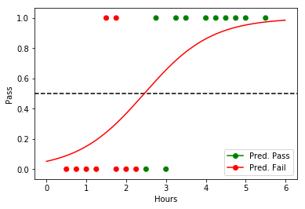

```
Positive, P       :  11
Negative, N       :  9


CONFUSION MATRIX
```

|  | pred:0 | pred:1 |
| --- | --- | --- |
| 0 | 7 | 2 |
| 1 | 2 | 9 |

[output not shown]

S/H

```python
from sklearn.metrics import confusion_matrix,recall_score,precision_score,accuracy_score,f1_score
from matplotlib.lines import Line2D
Yp = clf.predict_proba(X)
pp_pass = Yp[:,1]
dfp = df.copy(deep=True)
dfp['Pass Prob. Predicted'] = np.round(pp_pass,2)
T = 0.5
dfp['Prediction'] = [1 if x>=T else 0 for x in pp_pass]
dfp[["Prediction"]] = dfp[["Prediction"]].astype(int)
dfp_transpose = dfp.T
display(dfp_transpose)
color_array = ['red' if x==0 else 'green' for x in dfp['Prediction']]
plt.scatter(df.Hours,df.Pass,color=color_array)

legend_elements = [Line2D([0],[0],marker='o', color='g', label='Pred. Pass'),
                   Line2D([0], [0], marker='o', color='r', label='Pred. Fail')]
plt.legend(handles=legend_elements, loc='best')
plt.axhline(0.5,color='black',linestyle='--')
plt.plot(x,y,color='red')
plt.xlabel("Hours")
plt.ylabel("Pass")
plt.show()
print('Positive, P       : ',sum(dfp.Pass))
print('Negative, N       : ',len(dfp) - sum(dfp.Pass))
cm = confusion_matrix(dfp['Pass'],dfp['Prediction'])
#print(cm)
cmtx = pd.DataFrame(cm, index=['0', '1'], columns=['pred:0', 'pred:1'])
print('\n\nCONFUSION MATRIX')
display(cmtx)
print('True Positive, TP : ',cm[1][1])
print('True Negative, TN : ',cm[0][0])
print('False Positive,FP : ',cm[0][1])
print('False Negative,FN : ',cm[1][1])
print('Sensitivity(Recall):',np.round(recall_score(dfp['Pass'],dfp['Prediction']),2))
print('PPV(Precision):',np.round(precision_score(dfp['Pass'],dfp['Prediction']),2))
print('Specificity:',np.round(cm[0][0]/(len(dfp)-sum(dfp.Pass)),2))
print('Accuracy:',np.round(accuracy_score(dfp['Pass'],dfp['Prediction']),2))
print('F1 score:',np.round(f1_score(dfp['Pass'],dfp['Prediction']),2))
Toggle.hide_toggle()
```

##### Clearly, these metrics depend on threshold chosen. Is it possible to evaluate skill of model irrespective of threshold ?

##### One way is to look at Receiver Operating Characteristic (ROC) and then calculate Area Under Curve (AUC) for ROC. AUC will vary from 0 to 1. Closer the value of AUC is to 1, better is the model.

##### ROC also helps to chose threshold that best satisfy sensitivity - specificity requirement.

##### We generally choose threshold that maximizes TPR - FPR

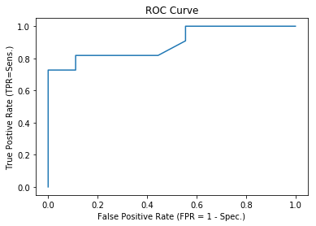

```
Area Under Curve :  0.894
```

S/H

```python
from sklearn.metrics import roc_curve,roc_auc_score
fpr, tpr,thresholds = roc_curve(dfp['Pass'],dfp['Pass Prob. Predicted'])
plt.plot(fpr,tpr)
plt.xlabel('False Positive Rate (FPR = 1 - Spec.)')
plt.ylabel('True Postive Rate (TPR=Sens.)')
plt.title('ROC Curve')
plt.show()
print('Area Under Curve : ', np.round(roc_auc_score(dfp['Pass'],dfp['Pass Prob. Predicted']),3))
Toggle.hide_toggle()
```

#### In above example we did Logistic Regression with single independent (explanatory) variable

#### Just as in Linear Regression we can have more than multiple explanatory variable in Logistic Regression

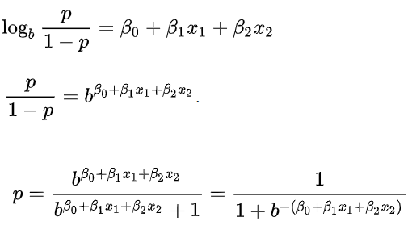

### References

https://en.wikipedia.org/wiki/Logistic_regression